# Topic 4 Exercises: Classification

Delia Walker-Jones

```r
library("ISLR")
library("MASS")
library("class")
```

## 4.7.11

### A

```r
Auto01 <- data.frame(Auto)

Auto01$mpg01 <- ifelse(Auto$mpg>median(Auto$mpg) & Auto$mpg>median(Auto$mpg), 1, 0)
table(Auto01$mpg01)
```

```
##
##   0   1
## 196 196
```

### B

```r
names(Auto01)
```

```
##  [1] "mpg"          "cylinders"    "displacement" "horsepower"
##  [5] "weight"       "acceleration" "year"         "origin"
##  [9] "name"         "mpg01"
```

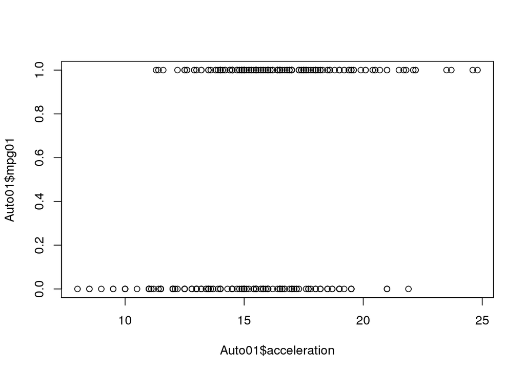

```r
plot(x = Auto01$acceleration, y = Auto01$mpg01)
```

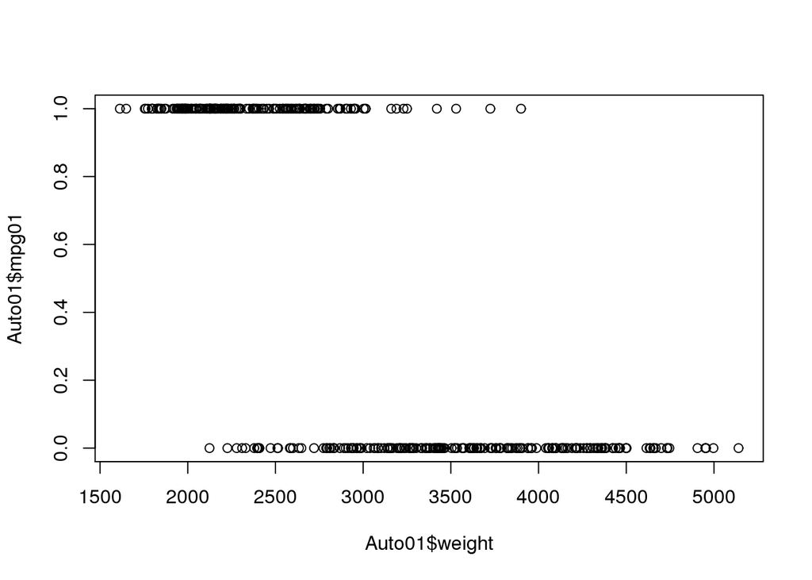

```r
plot(x = Auto01$weight, y = Auto01$mpg01)
```

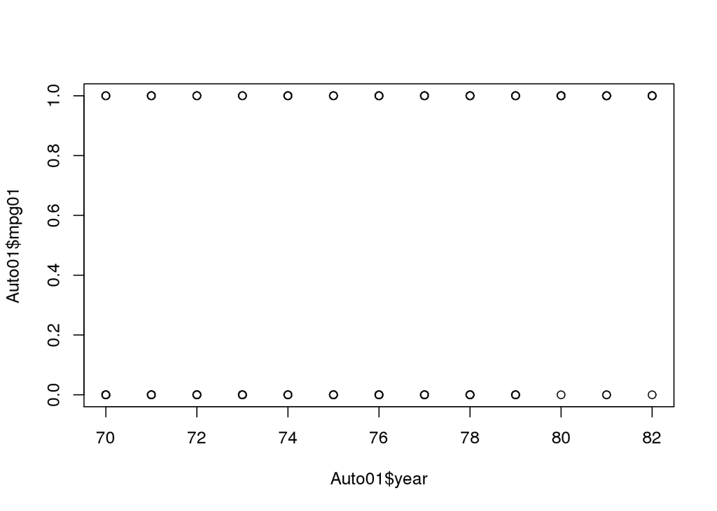

```r
plot(x = Auto01$year, y = Auto01$mpg01)
```

I looked briefly at acceleration, weight, and year to see how those might affect mpg. Acceleration appears to have some sort of relationship, with cars with lower acceleration having mpg below the median value. However, the acceleration variable appears pretty clustered in the 15-20mph range, so it might not be quite as interesting. I next looked at weight, which was interesting–lighter cars seem to be more likely to have mpg over the median, which seems counter-intuitive. There doesn’t seem to be any relationship between year and mpg, so I went with weight and acceleration as my explanatory variables.

### C

```r
train = Auto01$year<82
test = Auto01[!train,]
mpg01Test <- Auto01$mpg01[!train]
```

### D

```r
ldaMod = lda(mpg01 ~ weight + acceleration, data = Auto01, subset = train)
ldaMod
```

```
## Call:
## lda(mpg01 ~ weight + acceleration, data = Auto01, subset = train)
##
## Prior probabilities of groups:
##        0        1
## 0.538674 0.461326
##
## Group means:
##     weight acceleration
## 0 3624.431     14.58513
## 1 2319.904     16.48383
##
## Coefficients of linear discriminants:
##                       LD1
## weight       -0.001735179
## acceleration  0.019672859
```

```r
ldaPred = predict(ldaMod, test)
ldaPred
```

```
## $class
##  [1] 1 1 1 1 1 1 1 1 1 1 1 1 1 1 1 1 1 1 0 0 1 1 1 1 1 1 1 1 1 1
## Levels: 0 1
##
## $posterior
##              0         1
## 368 0.18317890 0.8168211
## 369 0.21249493 0.7875051
## 370 0.09440780 0.9055922
## 371 0.18834064 0.8116594
## 372 0.16091949 0.8390805
## 373 0.28833171 0.7116683
## 374 0.42261594 0.5773841
## 375 0.02197450 0.9780255
## 376 0.02303896 0.9769610
```

[output cut: 54 more lines]

```r
table(ldaPred$class, mpg01Test)
```

```
##    mpg01Test
##      0  1
##   0  0  2
##   1  1 27
```

```r
# Test error rate
mean(ldaPred$class != mpg01Test)
```

```
## [1] 0.1
```

We can conclude we have a test error rate of about 10%.

### E

```r
qdaMod = qda(mpg01 ~ weight + acceleration, data = Auto01, subset = train)
qdaMod
```

```
## Call:
## qda(mpg01 ~ weight + acceleration, data = Auto01, subset = train)
##
## Prior probabilities of groups:
##        0        1
## 0.538674 0.461326
##
## Group means:
##     weight acceleration
## 0 3624.431     14.58513
## 1 2319.904     16.48383
```

```r
qdaPred = predict(qdaMod, test)
qdaPred
```

```
## $class
##  [1] 1 1 1 1 1 1 1 1 1 1 1 1 1 1 1 1 1 1 0 0 1 1 1 1 0 1 1 1 1 1
## Levels: 0 1
##
## $posterior
##              0         1
## 368 0.19932970 0.8006703
## 369 0.22976461 0.7702354
## 370 0.12675846 0.8732415
## 371 0.21005570 0.7899443
## 372 0.18030177 0.8196982
## 373 0.30648835 0.6935116
## 374 0.48251016 0.5174898
## 375 0.03879274 0.9612073
## 376 0.06512750 0.9348725
```

[output cut: 21 more lines]

```r
table(qdaPred$class, mpg01Test)
```

```
##    mpg01Test
##      0  1
##   0  0  3
##   1  1 26
```

```r
# Test error rate
mean(qdaPred$class != mpg01Test)
```

```
## [1] 0.1333333
```

We have a test error of about 13.3%.

### F

```r
logMod = glm(mpg01 ~ weight + acceleration, data = Auto01, family = "binomial", subset = train)
summary(logMod)
```

```
##
## Call:
## glm(formula = mpg01 ~ weight + acceleration, family = "binomial",
##     data = Auto01, subset = train)
##
## Deviance Residuals:
##     Min       1Q   Median       3Q      Max
## -2.4127  -0.2945  -0.0269   0.3821   2.9162
##
## Coefficients:
##                Estimate Std. Error z value Pr(>|z|)
## (Intercept)   8.5045805  1.5284910   5.564 2.64e-08 ***
## weight       -0.0041745  0.0004548  -9.179  < 2e-16 ***
## acceleration  0.2033488  0.0789696   2.575     0.01 *
## ---
## Signif. codes:  0 '***' 0.001 '**' 0.01 '*' 0.05 '.' 0.1 ' ' 1
##
## (Dispersion parameter for binomial family taken to be 1)
##
##     Null deviance: 499.67  on 361  degrees of freedom
## Residual deviance: 202.52  on 359  degrees of freedom
## AIC: 208.52
##
## Number of Fisher Scoring iterations: 7
```

```r
logProb = predict(logMod, test, type = "response")
logPred = rep("Down", 30)
logPred[logProb >.5] = "Up"

table(logPred, mpg01Test)
```

```
##        mpg01Test
## logPred  0  1
##    Down  1  4
##    Up    0 25
```

```r
# Test error rate
mean(logPred != mpg01Test)
```

```
## [1] 1
```

### G

```r
trainX = cbind(Auto01$weight, Auto01$acceleration)[train,]
testX = cbind(Auto01$weight, Auto01$acceleration)[!train,]
trainMpg01 = Auto01$mpg01[train]


set.seed(1)
knnMod = knn(trainX, testX, trainMpg01, k=10)
summary(knnMod)
```

```
##  0  1
##  5 25
```

## 4.7.13

```r
Boston <- Boston
head(Boston)
```

```
##      crim zn indus chas   nox    rm  age    dis rad tax ptratio  black
## 1 0.00632 18  2.31    0 0.538 6.575 65.2 4.0900   1 296    15.3 396.90
## 2 0.02731  0  7.07    0 0.469 6.421 78.9 4.9671   2 242    17.8 396.90
## 3 0.02729  0  7.07    0 0.469 7.185 61.1 4.9671   2 242    17.8 392.83
## 4 0.03237  0  2.18    0 0.458 6.998 45.8 6.0622   3 222    18.7 394.63
## 5 0.06905  0  2.18    0 0.458 7.147 54.2 6.0622   3 222    18.7 396.90
## 6 0.02985  0  2.18    0 0.458 6.430 58.7 6.0622   3 222    18.7 394.12
##   lstat medv
## 1  4.98 24.0
## 2  9.14 21.6
## 3  4.03 34.7
## 4  2.94 33.4
## 5  5.33 36.2
## 6  5.21 28.7
```

```r
summary(Boston$crim)
```

```
##     Min.  1st Qu.   Median     Mean  3rd Qu.     Max.
##  0.00632  0.08204  0.25650  3.61400  3.67700 88.98000
```

```r
Boston$crim01 = ifelse(Boston$crim>median(Boston$crim) & Boston$crim>median(Boston$crim), 1, 0)
table(Boston$crim01)
```

```
##
##   0   1
## 253 253
```

We add a new variable, crim01, that consists of 1s and 0s representing crime rate above or below the median.

```r
set.seed(1)
train = sample(1:nrow(Boston), nrow(Boston)/2)
test = (-train)
crim01.test = Boston$crim01[test]
length(test)
```

```
## [1] 253
```

We divide the data into test and training data.

```r
glmMod = glm(crim01 ~.-crim01 - crim, data = Boston[train,], family = "binomial")
summary(glmMod)
```

```
##
## Call:
## glm(formula = crim01 ~ . - crim01 - crim, family = "binomial",
##     data = Boston[train, ])
##
## Deviance Residuals:
##     Min       1Q   Median       3Q      Max
## -1.5914  -0.1747  -0.0028   0.0037   3.4997
##
## Coefficients:
##               Estimate Std. Error z value Pr(>|z|)
## (Intercept) -44.492631  10.370769  -4.290 1.79e-05 ***
## zn           -0.044964   0.040574  -1.108   0.2678
## indus        -0.076522   0.068962  -1.110   0.2672
## chas          0.013430   1.047477   0.013   0.9898
## nox          52.722192  11.982655   4.400 1.08e-05 ***
## rm            0.339584   1.048227   0.324   0.7460
## age           0.047307   0.020520   2.305   0.0211 *
## dis           0.797836   0.336235   2.373   0.0177 *
## rad           0.522050   0.224384   2.327   0.0200 *
## tax          -0.007807   0.004375  -1.784   0.0744 .
## ptratio       0.324977   0.184932   1.757   0.0789 .
## black        -0.004292   0.005490  -0.782   0.4343
## lstat         0.068336   0.079535   0.859   0.3902
## medv          0.129651   0.098128   1.321   0.1864
## ---
## Signif. codes:  0 '***' 0.001 '**' 0.01 '*' 0.05 '.' 0.1 ' ' 1
##
## (Dispersion parameter for binomial family taken to be 1)
##
##     Null deviance: 350.729  on 252  degrees of freedom
## Residual deviance:  94.604  on 239  degrees of freedom
## AIC: 122.6
##
## Number of Fisher Scoring iterations: 9
```

```r
glmProb = predict(glmMod, Boston[test,], type = "response")
glmPred = rep(0, length(glmProb))
glmPred[glmProb > 0.5] <- 1
table(glmPred, crim01.test)
```

```
##        crim01.test
## glmPred   0   1
##       0 113  18
##       1  13 109
```

```r
mean(glmPred != crim01.test)
```

```
## [1] 0.1225296
```

Our error rate for logistic regression is about 12.25%.

```r
ldaMod = lda(crim01 ~.-crim01 - crim, data = Boston[train,])
ldaMod
```

```
## Call:
## lda(crim01 ~ . - crim01 - crim, data = Boston[train, ])
##
## Prior probabilities of groups:
##         0         1
## 0.5019763 0.4980237
##
## Group means:
##          zn     indus       chas       nox       rm      age      dis
## 0 20.968504  6.694331 0.06299213 0.4697220 6.426055 52.13701 4.968427
## 1  1.285714 15.635317 0.07936508 0.6469683 6.152286 87.05079 2.454815
##         rad      tax  ptratio    black     lstat     medv
## 0  4.464567 306.0709 17.72362 386.4537  9.356063 25.37402
## 1 15.857143 525.4841 18.99841 330.2035 16.067778 19.95079
##
## Coefficients of linear discriminants:
##                   LD1
## zn      -0.0032947512
## indus    0.0434688003
## chas    -0.3352572497
## nox      7.3086318809
## rm       0.2287315340
## age      0.0191931268
## dis      0.0851615065
## rad      0.0933334206
## tax     -0.0017364744
## ptratio  0.0072880576
## black   -0.0006269558
## lstat    0.0056904302
## medv     0.0288989726
```

```r
ldaPred = predict(ldaMod, Boston[test,])
ldaClass = ldaPred$class
table(ldaClass, crim01.test)
```

```
##         crim01.test
## ldaClass   0   1
##        0 119  35
##        1   7  92
```

```r
mean(ldaClass != crim01.test)
```

```
## [1] 0.1660079
```

For this LDA model, our error rate is about 16.6%.

```r
qdaMod = qda(crim01 ~.-crim01 - crim, data = Boston[train,])
qdaMod
```

```
## Call:
## qda(crim01 ~ . - crim01 - crim, data = Boston[train, ])
##
## Prior probabilities of groups:
##         0         1
## 0.5019763 0.4980237
##
## Group means:
##          zn     indus       chas       nox       rm      age      dis
## 0 20.968504  6.694331 0.06299213 0.4697220 6.426055 52.13701 4.968427
## 1  1.285714 15.635317 0.07936508 0.6469683 6.152286 87.05079 2.454815
##         rad      tax  ptratio    black     lstat     medv
## 0  4.464567 306.0709 17.72362 386.4537  9.356063 25.37402
## 1 15.857143 525.4841 18.99841 330.2035 16.067778 19.95079
```

```r
qdaPred = predict(qdaMod, Boston[test,])
table(qdaPred$class, crim01.test)
```

```
##    crim01.test
##       0   1
##   0 126  28
##   1   0  99
```

```r
mean(qdaPred$class != crim01.test)
```

```
## [1] 0.1106719
```

For this QDA model, we have an error rate of about 11%.

```r
set.seed(1)
trainX = cbind(Boston$zn, Boston$indus, Boston$chas, Boston$nox, Boston$rm, Boston$age, Boston$dis, Boston$rad, Boston$tax, Boston$ptratio, Boston$black, Boston$lstat, Boston$medv)[train,]
testX = cbind(Boston$zn, Boston$indus, Boston$chas, Boston$nox, Boston$rm, Boston$age, Boston$dis, Boston$rad, Boston$tax, Boston$ptratio, Boston$black, Boston$lstat, Boston$medv)[test,]
knnPred = knn(trainX, testX, Boston$crim01[train], k = 1)
table(knnPred, crim01.test)
```

```
##        crim01.test
## knnPred   0   1
##       0 114  11
##       1  12 116
```

```r
mean(knnPred != crim01.test)
```

```
## [1] 0.09090909
```

The error rate for k = 1 is about 9%.

```r
knnPred1 = knn(trainX, testX, Boston$crim01[train], k = 10)
table(knnPred1, crim01.test)
```

```
##         crim01.test
## knnPred1   0   1
##        0 109  21
##        1  17 106
```

```r
mean(knnPred1 != crim01.test)
```

```
## [1] 0.1501976
```

The error rate for k = 10 is about 15%.

```r
knnPred2 = knn(trainX, testX, Boston$crim01[train], k = 100)
table(knnPred2, crim01.test)
```

```
##         crim01.test
## knnPred2   0   1
##        0 123  66
##        1   3  61
```

```r
mean(knnPred2 != crim01.test)
```

```
## [1] 0.2727273
```

The error rate for k = 100 is about 27.3%.

## 4.7.1

Prove that  
p(X) = e^(B<sub>0</sub> + B<sub>1</sub>`*`X)/1 + e^(B<sub>0</sub> + B<sub>1</sub>`*`X)  
is equivalent to  
p(X)/1 - p(X) = e^(B<sub>0</sub> + B<sub>1</sub>`*`X)

p(X) `*` (1 + e^(B<sub>0</sub> + B<sub>1</sub>`*`X)) = e^(B<sub>0</sub> + B<sub>1</sub>`*`X)  
p(X) + (p(X) `*` e^(B<sub>0</sub> + B<sub>1</sub>`*`X)) = e^(B<sub>0</sub> + B<sub>1</sub>`*`X) p(X) - e^(B<sub>0</sub> + B<sub>1</sub>`*`X) = -(p(X) `*` e^(B<sub>0</sub> + B<sub>1</sub>`*`X))  
e^(B<sub>0</sub> + B<sub>1</sub>`*`X) = (p(X) `*` e^(B<sub>0</sub> + B<sub>1</sub>`*`X)) - p(X)  
e^(B<sub>0</sub> + B<sub>1</sub>`*`X) = p(X) `*` (e^(B<sub>0</sub> + B<sub>1</sub>`*`X) - 1)

## 4.7.8

The KNN (K = 1) approach, when used with in-sample testing–aka the training dataset–will result in 0% error, because the point is already present, so the “nearest neighbor” is predicted perfectly. However, because the error is 18% averaged over both the testing and training data sets, the error for the testing data is 36% (18 `*` 2). Therefore, the error for KNN is higher than that of the logistic regression model, and the logistic regression is the better fit for this particular data, suggesting that the decision boundaries are linear.

## 4.7.9

### A

p(X)/1 - p(X) = 0.37  
converted to  
p(X) = 0.37 / 1 + 0.37

```r
.37 / (1 + .37)
```

```
## [1] 0.270073
```

Therefore, p(X) = 0.27, meaning that 27% of people with an odds of .37 of defaulting will in fact default on their credit card payments.

### B

.16 / 1 - .16 = odds

```r
.16 / (1 - .16)
```

```
## [1] 0.1904762
```

Therefore, the odds of a person defaulting with a 16% chance of defaulting on their credit card payment are .19.